# Risk Factor Analysis

## Outcome Variable

**Outcome Variable:** sstunted

## Predictor Variables

**Intervention Variable:** mbmi

**Adjustment Set:**

unadjusted

## Stratifying Variables

The analysis was stratified on these variable(s):

- agecat
- studyid
- country

## Data Summary

| agecat | studyid | country | mbmi | sstunted | n_cell | n |
| --- | --- | --- | --- | --- | --- | --- |
| Birth | ki0047075b-MAL-ED | BANGLADESH | Normal weight | 0 | 188 | 222 |
| Birth | ki0047075b-MAL-ED | BANGLADESH | Normal weight | 1 | 6 | 222 |
| Birth | ki0047075b-MAL-ED | BANGLADESH | Underweight | 0 | 27 | 222 |
| Birth | ki0047075b-MAL-ED | BANGLADESH | Underweight | 1 | 1 | 222 |
| Birth | ki0047075b-MAL-ED | BRAZIL | Normal weight | 0 | 56 | 64 |
| Birth | ki0047075b-MAL-ED | BRAZIL | Normal weight | 1 | 3 | 64 |
| Birth | ki0047075b-MAL-ED | BRAZIL | Underweight | 0 | 5 | 64 |
| Birth | ki0047075b-MAL-ED | BRAZIL | Underweight | 1 | 0 | 64 |
| Birth | ki0047075b-MAL-ED | INDIA | Normal weight | 0 | 33 | 43 |
| Birth | ki0047075b-MAL-ED | INDIA | Normal weight | 1 | 2 | 43 |
| Birth | ki0047075b-MAL-ED | INDIA | Underweight | 0 | 8 | 43 |
| Birth | ki0047075b-MAL-ED | INDIA | Underweight | 1 | 0 | 43 |
| Birth | ki0047075b-MAL-ED | NEPAL | Normal weight | 0 | 26 | 27 |
| Birth | ki0047075b-MAL-ED | NEPAL | Normal weight | 1 | 1 | 27 |
| Birth | ki0047075b-MAL-ED | NEPAL | Underweight | 0 | 0 | 27 |
| Birth | ki0047075b-MAL-ED | NEPAL | Underweight | 1 | 0 | 27 |
| Birth | ki0047075b-MAL-ED | PERU | Normal weight | 0 | 218 | 226 |
| Birth | ki0047075b-MAL-ED | PERU | Normal weight | 1 | 3 | 226 |
| Birth | ki0047075b-MAL-ED | PERU | Underweight | 0 | 4 | 226 |
| Birth | ki0047075b-MAL-ED | PERU | Underweight | 1 | 1 | 226 |
| Birth | ki0047075b-MAL-ED | SOUTH AFRICA | Normal weight | 0 | 97 | 101 |
| Birth | ki0047075b-MAL-ED | SOUTH AFRICA | Normal weight | 1 | 1 | 101 |
| Birth | ki0047075b-MAL-ED | SOUTH AFRICA | Underweight | 0 | 3 | 101 |
| Birth | ki0047075b-MAL-ED | SOUTH AFRICA | Underweight | 1 | 0 | 101 |
| Birth | ki0047075b-MAL-ED | TANZANIA, UNITED REPUBLIC OF | Normal weight | 0 | 107 | 122 |
| Birth | ki0047075b-MAL-ED | TANZANIA, UNITED REPUBLIC OF | Normal weight | 1 | 8 | 122 |
| Birth | ki0047075b-MAL-ED | TANZANIA, UNITED REPUBLIC OF | Underweight | 0 | 6 | 122 |
| Birth | ki0047075b-MAL-ED | TANZANIA, UNITED REPUBLIC OF | Underweight | 1 | 1 | 122 |
| Birth | ki1000304b-SAS-CompFeed | INDIA | Normal weight | 0 | 768 | 1135 |
| Birth | ki1000304b-SAS-CompFeed | INDIA | Normal weight | 1 | 62 | 1135 |

[output cut: 150 more lines]

The following strata were considered:

- agecat: 24 months, studyid: ki0047075b-MAL-ED, country: BANGLADESH
- agecat: 24 months, studyid: ki0047075b-MAL-ED, country: BRAZIL
- agecat: 24 months, studyid: ki0047075b-MAL-ED, country: INDIA
- agecat: 24 months, studyid: ki0047075b-MAL-ED, country: NEPAL
- agecat: 24 months, studyid: ki0047075b-MAL-ED, country: PERU
- agecat: 24 months, studyid: ki0047075b-MAL-ED, country: SOUTH AFRICA
- agecat: 24 months, studyid: ki0047075b-MAL-ED, country: TANZANIA, UNITED REPUBLIC OF
- agecat: 24 months, studyid: ki1017093-NIH-Birth, country: BANGLADESH
- agecat: 24 months, studyid: ki1017093b-PROVIDE, country: BANGLADESH
- agecat: 24 months, studyid: ki1017093c-NIH-Crypto, country: BANGLADESH
- agecat: 24 months, studyid: ki1066203-TanzaniaChild2, country: TANZANIA, UNITED REPUBLIC OF
- agecat: 24 months, studyid: ki1119695-PROBIT, country: BELARUS
- agecat: 24 months, studyid: ki1126311-ZVITAMBO, country: ZIMBABWE
- agecat: 24 months, studyid: ki1148112-LCNI-5, country: MALAWI
- agecat: 24 months, studyid: kiGH5241-JiVitA-3, country: BANGLADESH
- agecat: 6 months, studyid: ki0047075b-MAL-ED, country: BANGLADESH
- agecat: 6 months, studyid: ki0047075b-MAL-ED, country: BRAZIL
- agecat: 6 months, studyid: ki0047075b-MAL-ED, country: INDIA
- agecat: 6 months, studyid: ki0047075b-MAL-ED, country: NEPAL
- agecat: 6 months, studyid: ki0047075b-MAL-ED, country: PERU
- agecat: 6 months, studyid: ki0047075b-MAL-ED, country: SOUTH AFRICA
- agecat: 6 months, studyid: ki0047075b-MAL-ED, country: TANZANIA, UNITED REPUBLIC OF
- agecat: 6 months, studyid: ki1000304b-SAS-CompFeed, country: INDIA
- agecat: 6 months, studyid: ki1017093-NIH-Birth, country: BANGLADESH
- agecat: 6 months, studyid: ki1017093b-PROVIDE, country: BANGLADESH
- agecat: 6 months, studyid: ki1017093c-NIH-Crypto, country: BANGLADESH
- agecat: 6 months, studyid: ki1066203-TanzaniaChild2, country: TANZANIA, UNITED REPUBLIC OF
- agecat: 6 months, studyid: ki1119695-PROBIT, country: BELARUS
- agecat: 6 months, studyid: ki1126311-ZVITAMBO, country: ZIMBABWE
- agecat: 6 months, studyid: ki1148112-LCNI-5, country: MALAWI
- agecat: 6 months, studyid: kiGH5241-JiVitA-3, country: BANGLADESH
- agecat: Birth, studyid: ki0047075b-MAL-ED, country: BANGLADESH
- agecat: Birth, studyid: ki0047075b-MAL-ED, country: BRAZIL
- agecat: Birth, studyid: ki0047075b-MAL-ED, country: INDIA
- agecat: Birth, studyid: ki0047075b-MAL-ED, country: NEPAL
- agecat: Birth, studyid: ki0047075b-MAL-ED, country: PERU
- agecat: Birth, studyid: ki0047075b-MAL-ED, country: SOUTH AFRICA
- agecat: Birth, studyid: ki0047075b-MAL-ED, country: TANZANIA, UNITED REPUBLIC OF
- agecat: Birth, studyid: ki1000304b-SAS-CompFeed, country: INDIA
- agecat: Birth, studyid: ki1017093-NIH-Birth, country: BANGLADESH
- agecat: Birth, studyid: ki1017093b-PROVIDE, country: BANGLADESH
- agecat: Birth, studyid: ki1017093c-NIH-Crypto, country: BANGLADESH
- agecat: Birth, studyid: ki1119695-PROBIT, country: BELARUS
- agecat: Birth, studyid: ki1126311-ZVITAMBO, country: ZIMBABWE
- agecat: Birth, studyid: kiGH5241-JiVitA-3, country: BANGLADESH

### Dropped Strata

Some strata were dropped due to rare outcomes:

- agecat: Birth, studyid: ki0047075b-MAL-ED, country: BANGLADESH
- agecat: Birth, studyid: ki0047075b-MAL-ED, country: BRAZIL
- agecat: Birth, studyid: ki0047075b-MAL-ED, country: INDIA
- agecat: Birth, studyid: ki0047075b-MAL-ED, country: NEPAL
- agecat: Birth, studyid: ki0047075b-MAL-ED, country: PERU
- agecat: Birth, studyid: ki0047075b-MAL-ED, country: SOUTH AFRICA
- agecat: Birth, studyid: ki0047075b-MAL-ED, country: TANZANIA, UNITED REPUBLIC OF
- agecat: Birth, studyid: ki1017093b-PROVIDE, country: BANGLADESH
- agecat: Birth, studyid: ki1017093c-NIH-Crypto, country: BANGLADESH
- agecat: Birth, studyid: ki1119695-PROBIT, country: BELARUS
- agecat: 6 months, studyid: ki0047075b-MAL-ED, country: BANGLADESH
- agecat: 6 months, studyid: ki0047075b-MAL-ED, country: BRAZIL
- agecat: 6 months, studyid: ki0047075b-MAL-ED, country: INDIA
- agecat: 6 months, studyid: ki0047075b-MAL-ED, country: NEPAL
- agecat: 6 months, studyid: ki0047075b-MAL-ED, country: PERU
- agecat: 6 months, studyid: ki0047075b-MAL-ED, country: SOUTH AFRICA
- agecat: 6 months, studyid: ki0047075b-MAL-ED, country: TANZANIA, UNITED REPUBLIC OF
- agecat: 6 months, studyid: ki1017093b-PROVIDE, country: BANGLADESH
- agecat: 6 months, studyid: ki1066203-TanzaniaChild2, country: TANZANIA, UNITED REPUBLIC OF
- agecat: 24 months, studyid: ki0047075b-MAL-ED, country: BRAZIL
- agecat: 24 months, studyid: ki0047075b-MAL-ED, country: INDIA
- agecat: 24 months, studyid: ki0047075b-MAL-ED, country: NEPAL
- agecat: 24 months, studyid: ki0047075b-MAL-ED, country: PERU
- agecat: 24 months, studyid: ki0047075b-MAL-ED, country: SOUTH AFRICA
- agecat: 24 months, studyid: ki0047075b-MAL-ED, country: TANZANIA, UNITED REPUBLIC OF
- agecat: 24 months, studyid: ki1066203-TanzaniaChild2, country: TANZANIA, UNITED REPUBLIC OF
- agecat: 24 months, studyid: ki1119695-PROBIT, country: BELARUS

## Methods Detail

We’re interested in the causal parameters $E[Y_a]$ for all values of $a \in \mathcal{A}$. These parameters represent the mean outcome if, possibly contrary to fact, we intervened to set all units to have $A=a$. Under the randomization and positivity assumptions, these are identified by the statistical parameters $\psi_a=E_W[E_{Y|A,W}(Y|A=a,W)]$. In addition, we’re interested in the mean of $Y$, $E[Y]$ under no intervention (the observed mean). We will estimate these parameters by using SuperLearner to fit the relevant likelihood factors – $E_{Y|A,W}(Y|A=a,W)$ and $p(A=a|W)$, and then updating our likelihood fit using a joint TMLE.

For unadjusted analyses ($W=\{\}$), initial likelihoods were estimated using Lrnr_glm to estimate the simple $E(Y|A)$ and Lrnr_mean to estimate $p(A)$. For adjusted analyses, a small library containing Lrnr_glmnet, Lrnr_xgboost, and Lrnr_mean was used.

Having estimated these parameters, we will then use the delta method to estimate relative risks and attributable risks relative to a prespecified baseline level of $A$.

# Results Detail

## Results Plots

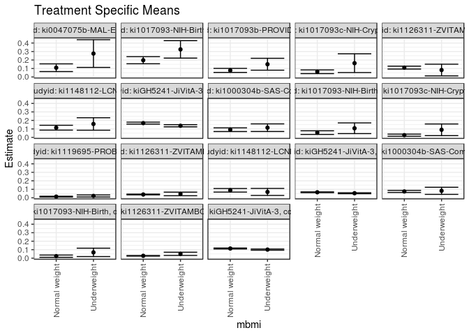

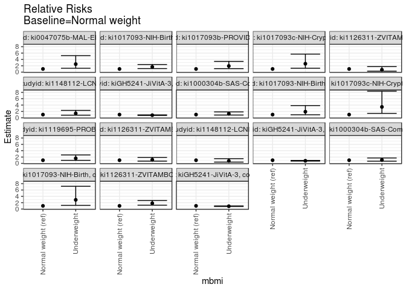

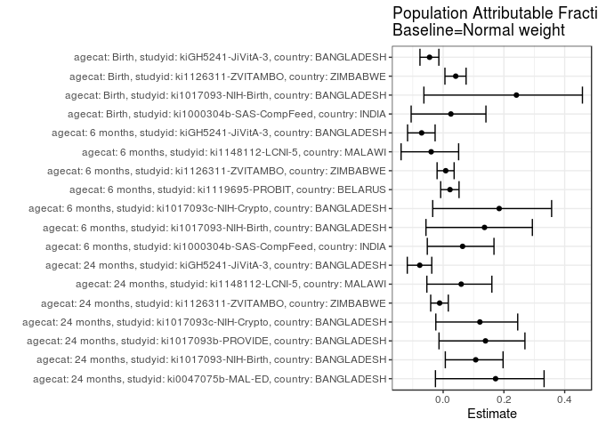

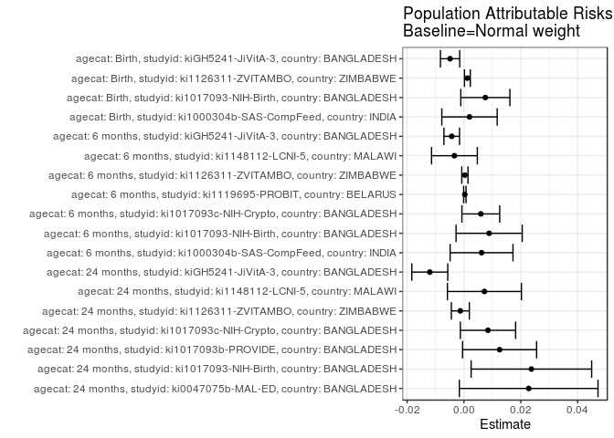

## Results Table

### Parameter: TSM

| agecat | studyid | country | intervention_level | baseline_level | estimate | ci_lower | ci_upper |
| --- | --- | --- | --- | --- | --- | --- | --- |
| Birth | ki1000304b-SAS-CompFeed | INDIA | Normal weight | NA | 0.0746988 | 0.0627901 | 0.0866075 |
| Birth | ki1000304b-SAS-CompFeed | INDIA | Underweight | NA | 0.0819672 | 0.0402254 | 0.1237091 |
| Birth | ki1017093-NIH-Birth | BANGLADESH | Normal weight | NA | 0.0237154 | 0.0104465 | 0.0369843 |
| Birth | ki1017093-NIH-Birth | BANGLADESH | Underweight | NA | 0.0686275 | 0.0195235 | 0.1177314 |
| Birth | ki1126311-ZVITAMBO | ZIMBABWE | Normal weight | NA | 0.0280506 | 0.0246695 | 0.0314318 |
| Birth | ki1126311-ZVITAMBO | ZIMBABWE | Underweight | NA | 0.0509804 | 0.0318896 | 0.0700712 |
| Birth | kiGH5241-JiVitA-3 | BANGLADESH | Normal weight | NA | 0.1138484 | 0.1081104 | 0.1195864 |
| Birth | kiGH5241-JiVitA-3 | BANGLADESH | Underweight | NA | 0.1012160 | 0.0942647 | 0.1081673 |
| 6 months | ki1000304b-SAS-CompFeed | INDIA | Normal weight | NA | 0.0907080 | 0.0689886 | 0.1124273 |
| 6 months | ki1000304b-SAS-CompFeed | INDIA | Underweight | NA | 0.1141975 | 0.0694264 | 0.1589687 |
| 6 months | ki1017093-NIH-Birth | BANGLADESH | Normal weight | NA | 0.0563063 | 0.0348450 | 0.0777676 |
| 6 months | ki1017093-NIH-Birth | BANGLADESH | Underweight | NA | 0.1075269 | 0.0445085 | 0.1705453 |
| 6 months | ki1017093c-NIH-Crypto | BANGLADESH | Normal weight | NA | 0.0262346 | 0.0139197 | 0.0385494 |
| 6 months | ki1017093c-NIH-Crypto | BANGLADESH | Underweight | NA | 0.0895522 | 0.0211327 | 0.1579718 |
| 6 months | ki1119695-PROBIT | BELARUS | Normal weight | NA | 0.0136560 | 0.0088978 | 0.0184141 |
| 6 months | ki1119695-PROBIT | BELARUS | Underweight | NA | 0.0217822 | 0.0098698 | 0.0336945 |
| 6 months | ki1126311-ZVITAMBO | ZIMBABWE | Normal weight | NA | 0.0387198 | 0.0341997 | 0.0432399 |
| 6 months | ki1126311-ZVITAMBO | ZIMBABWE | Underweight | NA | 0.0452128 | 0.0242104 | 0.0662151 |
| 6 months | ki1148112-LCNI-5 | MALAWI | Normal weight | NA | 0.0882779 | 0.0671125 | 0.1094432 |
| 6 months | ki1148112-LCNI-5 | MALAWI | Underweight | NA | 0.0689655 | 0.0276966 | 0.1102344 |
| 6 months | kiGH5241-JiVitA-3 | BANGLADESH | Normal weight | NA | 0.0649791 | 0.0601458 | 0.0698125 |
| 6 months | kiGH5241-JiVitA-3 | BANGLADESH | Underweight | NA | 0.0538068 | 0.0480944 | 0.0595191 |
| 24 months | ki0047075b-MAL-ED | BANGLADESH | Normal weight | NA | 0.1092896 | 0.0639783 | 0.1546010 |
| 24 months | ki0047075b-MAL-ED | BANGLADESH | Underweight | NA | 0.2758621 | 0.1128077 | 0.4389164 |
| 24 months | ki1017093-NIH-Birth | BANGLADESH | Normal weight | NA | 0.1977077 | 0.1558746 | 0.2395409 |
| 24 months | ki1017093-NIH-Birth | BANGLADESH | Underweight | NA | 0.3250000 | 0.2222449 | 0.4277551 |
| 24 months | ki1017093b-PROVIDE | BANGLADESH | Normal weight | NA | 0.0775681 | 0.0535425 | 0.1015937 |
| 24 months | ki1017093b-PROVIDE | BANGLADESH | Underweight | NA | 0.1500000 | 0.0799546 | 0.2200454 |
| 24 months | ki1017093c-NIH-Crypto | BANGLADESH | Normal weight | NA | 0.0615711 | 0.0398416 | 0.0833006 |
| 24 months | ki1017093c-NIH-Crypto | BANGLADESH | Underweight | NA | 0.1627907 | 0.0523400 | 0.2732414 |
| 24 months | ki1126311-ZVITAMBO | ZIMBABWE | Normal weight | NA | 0.1105183 | 0.0935466 | 0.1274900 |
| 24 months | ki1126311-ZVITAMBO | ZIMBABWE | Underweight | NA | 0.0819673 | 0.0131035 | 0.1508310 |
| 24 months | ki1148112-LCNI-5 | MALAWI | Normal weight | NA | 0.1141079 | 0.0856993 | 0.1425165 |
| 24 months | ki1148112-LCNI-5 | MALAWI | Underweight | NA | 0.1578947 | 0.0845059 | 0.2312836 |
| 24 months | kiGH5241-JiVitA-3 | BANGLADESH | Normal weight | NA | 0.1680847 | 0.1567197 | 0.1794497 |
| 24 months | kiGH5241-JiVitA-3 | BANGLADESH | Underweight | NA | 0.1368580 | 0.1242772 | 0.1494388 |

### Parameter: E(Y)

| agecat | studyid | country | intervention_level | baseline_level | estimate | ci_lower | ci_upper |
| --- | --- | --- | --- | --- | --- | --- | --- |
| Birth | ki1000304b-SAS-CompFeed | INDIA | NA | NA | 0.0766520 | 0.0591565 | 0.0941474 |
| Birth | ki1017093-NIH-Birth | BANGLADESH | NA | NA | 0.0312500 | 0.0174085 | 0.0450915 |
| Birth | ki1126311-ZVITAMBO | ZIMBABWE | NA | NA | 0.0292597 | 0.0259008 | 0.0326186 |
| Birth | kiGH5241-JiVitA-3 | BANGLADESH | NA | NA | 0.1089689 | 0.1044172 | 0.1135206 |
| 6 months | ki1000304b-SAS-CompFeed | INDIA | NA | NA | 0.0969055 | 0.0737418 | 0.1200693 |
| 6 months | ki1017093-NIH-Birth | BANGLADESH | NA | NA | 0.0651769 | 0.0442802 | 0.0860736 |
| 6 months | ki1017093c-NIH-Crypto | BANGLADESH | NA | NA | 0.0321678 | 0.0192256 | 0.0451101 |
| 6 months | ki1119695-PROBIT | BELARUS | NA | NA | 0.0139710 | 0.0092040 | 0.0187379 |
| 6 months | ki1126311-ZVITAMBO | ZIMBABWE | NA | NA | 0.0390508 | 0.0346294 | 0.0434723 |
| 6 months | ki1148112-LCNI-5 | MALAWI | NA | NA | 0.0849282 | 0.0660197 | 0.1038368 |
| 6 months | kiGH5241-JiVitA-3 | BANGLADESH | NA | NA | 0.0606802 | 0.0568207 | 0.0645397 |
| 24 months | ki0047075b-MAL-ED | BANGLADESH | NA | NA | 0.1320755 | 0.0863920 | 0.1777589 |
| 24 months | ki1017093-NIH-Birth | BANGLADESH | NA | NA | 0.2214452 | 0.1821080 | 0.2607825 |
| 24 months | ki1017093b-PROVIDE | BANGLADESH | NA | NA | 0.0901213 | 0.0667360 | 0.1135066 |
| 24 months | ki1017093c-NIH-Crypto | BANGLADESH | NA | NA | 0.0700389 | 0.0479542 | 0.0921236 |
| 24 months | ki1126311-ZVITAMBO | ZIMBABWE | NA | NA | 0.1092498 | 0.0927432 | 0.1257565 |
| 24 months | ki1148112-LCNI-5 | MALAWI | NA | NA | 0.1213172 | 0.0946538 | 0.1479805 |
| 24 months | kiGH5241-JiVitA-3 | BANGLADESH | NA | NA | 0.1560647 | 0.1473093 | 0.1648200 |

### Parameter: RR

| agecat | studyid | country | intervention_level | baseline_level | estimate | ci_lower | ci_upper |
| --- | --- | --- | --- | --- | --- | --- | --- |
| Birth | ki1000304b-SAS-CompFeed | INDIA | Normal weight | Normal weight | 1.0000000 | 1.0000000 | 1.0000000 |
| Birth | ki1000304b-SAS-CompFeed | INDIA | Underweight | Normal weight | 1.0973030 | 0.7041975 | 1.7098524 |
| Birth | ki1017093-NIH-Birth | BANGLADESH | Normal weight | Normal weight | 1.0000000 | 1.0000000 | 1.0000000 |
| Birth | ki1017093-NIH-Birth | BANGLADESH | Underweight | Normal weight | 2.8937908 | 1.1668052 | 7.1768839 |
| Birth | ki1126311-ZVITAMBO | ZIMBABWE | Normal weight | Normal weight | 1.0000000 | 1.0000000 | 1.0000000 |
| Birth | ki1126311-ZVITAMBO | ZIMBABWE | Underweight | Normal weight | 1.8174411 | 1.2263396 | 2.6934562 |
| Birth | kiGH5241-JiVitA-3 | BANGLADESH | Normal weight | Normal weight | 1.0000000 | 1.0000000 | 1.0000000 |
| Birth | kiGH5241-JiVitA-3 | BANGLADESH | Underweight | Normal weight | 0.8890418 | 0.8184108 | 0.9657685 |
| 6 months | ki1000304b-SAS-CompFeed | INDIA | Normal weight | Normal weight | 1.0000000 | 1.0000000 | 1.0000000 |
| 6 months | ki1000304b-SAS-CompFeed | INDIA | Underweight | Normal weight | 1.2589581 | 0.8600107 | 1.8429720 |
| 6 months | ki1017093-NIH-Birth | BANGLADESH | Normal weight | Normal weight | 1.0000000 | 1.0000000 | 1.0000000 |
| 6 months | ki1017093-NIH-Birth | BANGLADESH | Underweight | Normal weight | 1.9096774 | 0.9491610 | 3.8422016 |
| 6 months | ki1017093c-NIH-Crypto | BANGLADESH | Normal weight | Normal weight | 1.0000000 | 1.0000000 | 1.0000000 |
| 6 months | ki1017093c-NIH-Crypto | BANGLADESH | Underweight | Normal weight | 3.4135206 | 1.3924201 | 8.3682526 |
| 6 months | ki1119695-PROBIT | BELARUS | Normal weight | Normal weight | 1.0000000 | 1.0000000 | 1.0000000 |
| 6 months | ki1119695-PROBIT | BELARUS | Underweight | Normal weight | 1.5950669 | 0.9540085 | 2.6668928 |
| 6 months | ki1126311-ZVITAMBO | ZIMBABWE | Normal weight | Normal weight | 1.0000000 | 1.0000000 | 1.0000000 |
| 6 months | ki1126311-ZVITAMBO | ZIMBABWE | Underweight | Normal weight | 1.1676906 | 0.7232947 | 1.8851256 |
| 6 months | ki1148112-LCNI-5 | MALAWI | Normal weight | Normal weight | 1.0000000 | 1.0000000 | 1.0000000 |
| 6 months | ki1148112-LCNI-5 | MALAWI | Underweight | Normal weight | 0.7812323 | 0.4100294 | 1.4884884 |
| 6 months | kiGH5241-JiVitA-3 | BANGLADESH | Normal weight | Normal weight | 1.0000000 | 1.0000000 | 1.0000000 |
| 6 months | kiGH5241-JiVitA-3 | BANGLADESH | Underweight | Normal weight | 0.8280624 | 0.7315599 | 0.9372949 |
| 24 months | ki0047075b-MAL-ED | BANGLADESH | Normal weight | Normal weight | 1.0000000 | 1.0000000 | 1.0000000 |
| 24 months | ki0047075b-MAL-ED | BANGLADESH | Underweight | Normal weight | 2.5241379 | 1.2261968 | 5.1959623 |
| 24 months | ki1017093-NIH-Birth | BANGLADESH | Normal weight | Normal weight | 1.0000000 | 1.0000000 | 1.0000000 |
| 24 months | ki1017093-NIH-Birth | BANGLADESH | Underweight | Normal weight | 1.6438406 | 1.1236657 | 2.4048182 |
| 24 months | ki1017093b-PROVIDE | BANGLADESH | Normal weight | Normal weight | 1.0000000 | 1.0000000 | 1.0000000 |
| 24 months | ki1017093b-PROVIDE | BANGLADESH | Underweight | Normal weight | 1.9337838 | 1.1042038 | 3.3866210 |
| 24 months | ki1017093c-NIH-Crypto | BANGLADESH | Normal weight | Normal weight | 1.0000000 | 1.0000000 | 1.0000000 |
| 24 months | ki1017093c-NIH-Crypto | BANGLADESH | Underweight | Normal weight | 2.6439455 | 1.2305873 | 5.6805785 |
| 24 months | ki1126311-ZVITAMBO | ZIMBABWE | Normal weight | Normal weight | 1.0000000 | 1.0000000 | 1.0000000 |
| 24 months | ki1126311-ZVITAMBO | ZIMBABWE | Underweight | Normal weight | 0.7416623 | 0.3157143 | 1.7422811 |
| 24 months | ki1148112-LCNI-5 | MALAWI | Normal weight | Normal weight | 1.0000000 | 1.0000000 | 1.0000000 |
| 24 months | ki1148112-LCNI-5 | MALAWI | Underweight | Normal weight | 1.3837321 | 0.8166951 | 2.3444667 |
| 24 months | kiGH5241-JiVitA-3 | BANGLADESH | Normal weight | Normal weight | 1.0000000 | 1.0000000 | 1.0000000 |
| 24 months | kiGH5241-JiVitA-3 | BANGLADESH | Underweight | Normal weight | 0.8142205 | 0.7289726 | 0.9094374 |

### Parameter: PAR

| agecat | studyid | country | intervention_level | baseline_level | estimate | ci_lower | ci_upper |
| --- | --- | --- | --- | --- | --- | --- | --- |
| Birth | ki1000304b-SAS-CompFeed | INDIA | Normal weight | NA | 0.0019532 | -0.0077903 | 0.0116967 |
| Birth | ki1017093-NIH-Birth | BANGLADESH | Normal weight | NA | 0.0075346 | -0.0011025 | 0.0161717 |
| Birth | ki1126311-ZVITAMBO | ZIMBABWE | Normal weight | NA | 0.0012091 | 0.0001817 | 0.0022365 |
| Birth | kiGH5241-JiVitA-3 | BANGLADESH | Normal weight | NA | -0.0048795 | -0.0082645 | -0.0014945 |
| 6 months | ki1000304b-SAS-CompFeed | INDIA | Normal weight | NA | 0.0061976 | -0.0048628 | 0.0172579 |
| 6 months | ki1017093-NIH-Birth | BANGLADESH | Normal weight | NA | 0.0088706 | -0.0027749 | 0.0205161 |
| 6 months | ki1017093c-NIH-Crypto | BANGLADESH | Normal weight | NA | 0.0059333 | -0.0007202 | 0.0125867 |
| 6 months | ki1119695-PROBIT | BELARUS | Normal weight | NA | 0.0003150 | -0.0001001 | 0.0007301 |
| 6 months | ki1126311-ZVITAMBO | ZIMBABWE | Normal weight | NA | 0.0003310 | -0.0007647 | 0.0014268 |
| 6 months | ki1148112-LCNI-5 | MALAWI | Normal weight | NA | -0.0033496 | -0.0114093 | 0.0047100 |
| 6 months | kiGH5241-JiVitA-3 | BANGLADESH | Normal weight | NA | -0.0042990 | -0.0070461 | -0.0015518 |
| 24 months | ki0047075b-MAL-ED | BANGLADESH | Normal weight | NA | 0.0227859 | -0.0016183 | 0.0471900 |
| 24 months | ki1017093-NIH-Birth | BANGLADESH | Normal weight | NA | 0.0237375 | 0.0025221 | 0.0449529 |
| 24 months | ki1017093b-PROVIDE | BANGLADESH | Normal weight | NA | 0.0125532 | -0.0004745 | 0.0255809 |
| 24 months | ki1017093c-NIH-Crypto | BANGLADESH | Normal weight | NA | 0.0084678 | -0.0012566 | 0.0181922 |
| 24 months | ki1126311-ZVITAMBO | ZIMBABWE | Normal weight | NA | -0.0012685 | -0.0044349 | 0.0018979 |
| 24 months | ki1148112-LCNI-5 | MALAWI | Normal weight | NA | 0.0072093 | -0.0058152 | 0.0202337 |
| 24 months | kiGH5241-JiVitA-3 | BANGLADESH | Normal weight | NA | -0.0120200 | -0.0183465 | -0.0056935 |

### Parameter: PAF

| agecat | studyid | country | intervention_level | baseline_level | estimate | ci_lower | ci_upper |
| --- | --- | --- | --- | --- | --- | --- | --- |
| Birth | ki1000304b-SAS-CompFeed | INDIA | Normal weight | NA | 0.0254812 | -0.1053349 | 0.1408153 |
| Birth | ki1017093-NIH-Birth | BANGLADESH | Normal weight | NA | 0.2411067 | -0.0633857 | 0.4584100 |
| Birth | ki1126311-ZVITAMBO | ZIMBABWE | Normal weight | NA | 0.0413222 | 0.0058724 | 0.0755079 |
| Birth | kiGH5241-JiVitA-3 | BANGLADESH | Normal weight | NA | -0.0447787 | -0.0763200 | -0.0141617 |
| 6 months | ki1000304b-SAS-CompFeed | INDIA | Normal weight | NA | 0.0639548 | -0.0521849 | 0.1672750 |
| 6 months | ki1017093-NIH-Birth | BANGLADESH | Normal weight | NA | 0.1361004 | -0.0565698 | 0.2936363 |
| 6 months | ki1017093c-NIH-Crypto | BANGLADESH | Normal weight | NA | 0.1844471 | -0.0343640 | 0.3569706 |
| 6 months | ki1119695-PROBIT | BELARUS | Normal weight | NA | 0.0225480 | -0.0081287 | 0.0522912 |
| 6 months | ki1126311-ZVITAMBO | ZIMBABWE | Normal weight | NA | 0.0084769 | -0.0199684 | 0.0361289 |
| 6 months | ki1148112-LCNI-5 | MALAWI | Normal weight | NA | -0.0394407 | -0.1384473 | 0.0509556 |
| 6 months | kiGH5241-JiVitA-3 | BANGLADESH | Normal weight | NA | -0.0708461 | -0.1171200 | -0.0264891 |
| 24 months | ki0047075b-MAL-ED | BANGLADESH | Normal weight | NA | 0.1725215 | -0.0253527 | 0.3322096 |
| 24 months | ki1017093-NIH-Birth | BANGLADESH | Normal weight | NA | 0.1071935 | 0.0071013 | 0.1971955 |
| 24 months | ki1017093b-PROVIDE | BANGLADESH | Normal weight | NA | 0.1392920 | -0.0136307 | 0.2691439 |
| 24 months | ki1017093c-NIH-Crypto | BANGLADESH | Normal weight | NA | 0.1209012 | -0.0241135 | 0.2453817 |
| 24 months | ki1126311-ZVITAMBO | ZIMBABWE | Normal weight | NA | -0.0116108 | -0.0409718 | 0.0169221 |
| 24 months | ki1148112-LCNI-5 | MALAWI | Normal weight | NA | 0.0594250 | -0.0536400 | 0.1603572 |
| 24 months | kiGH5241-JiVitA-3 | BANGLADESH | Normal weight | NA | -0.0770197 | -0.1180627 | -0.0374833 |